# PITcleanr Workshop

Ryan N. Kinzer

Mike Ackerman

Kevin See

25 January, 2024

# 1 Introduction

PIT-tag data is often difficult to summarize into meaningful information due to the large amount of tag observations. For instance, PTAGIS serves as a data repository containing a single record for every observation of a tag code; including the initial detection, or “mark”, when the tag is implanted, and all subsequent detections on each antenna the tag passes, or at recapture (e.g., at weirs), and recovery (e.g., carcass surveys) sites. The number of detections that exist for each individual tag code can easily be in excess of 1,000s of observations. Therefore, querying PTAGIS for all detections of a large number of tags often lends to a wealth of data that is unwieldy to process. `PITcleanr` aims to “compress” or minimize the data to a more manageable size, without losing any of the information contained in the full dataset, and to provide useful tools to help organize the data into fish pathways and stream networks.

This document serves as a tutorial to the most common functions contained with `PITcleanr` and provides some simple data summaries that may help you get started using the package, and performing your own PIT-tag data analyses. The workshop contains four sections: querying data, compressing tag observations, developing fish pathways, and finally an example case study.

## 1.1 Installation

`PITcleanr` can be installed from GitHub using the R `remotes` package. Additional information on package installation can be found on the website [README](https://github.com/KevinSee/PITcleanr).

```r
## # install PITcleanr, if necessary
## install.packages("remotes")
## remotes::install_github("KevinSee/PITcleanr",
##                          build_vignettes = TRUE)
```

## 1.2 Load Packages

Once `PITcleanr` is successfully installed it can be loaded into the R session using the `library()` function. In this workshop, we will also use functions from the following packages; `tidyverse`, `sf`, and `kableExtra`. Use the `install.packages()` function for packages that are not already installed.

```r
# E.g., for packages not installed:
# install.packages(c("tidyverse", "sf"))

# load necessary packages
library(PITcleanr)
library(tidyverse)
library(sf)
library(kableExtra)
```

# 2 Query Site Data

## 2.1 Interrogation Sites

You can use `PITcleanr` to query and download metadata for PTAGIS interrogation sites using the function `queryInterrogationMeta()`. The `site_code` argument is used to specify sites; alternatively, set `site_code = NULL` to retrieve metadata for all sites.

```r
# interrogation site metadata
int_meta_KRS = queryInterrogationMeta(site_code = "KRS")
int_meta = queryInterrogationMeta(site_code = NULL)
```

As a simple example, after downloading the interrogation metadata you can quickly summarize the number of active instream remote detections systems in PTAGIS by organization using tidyverse functions.

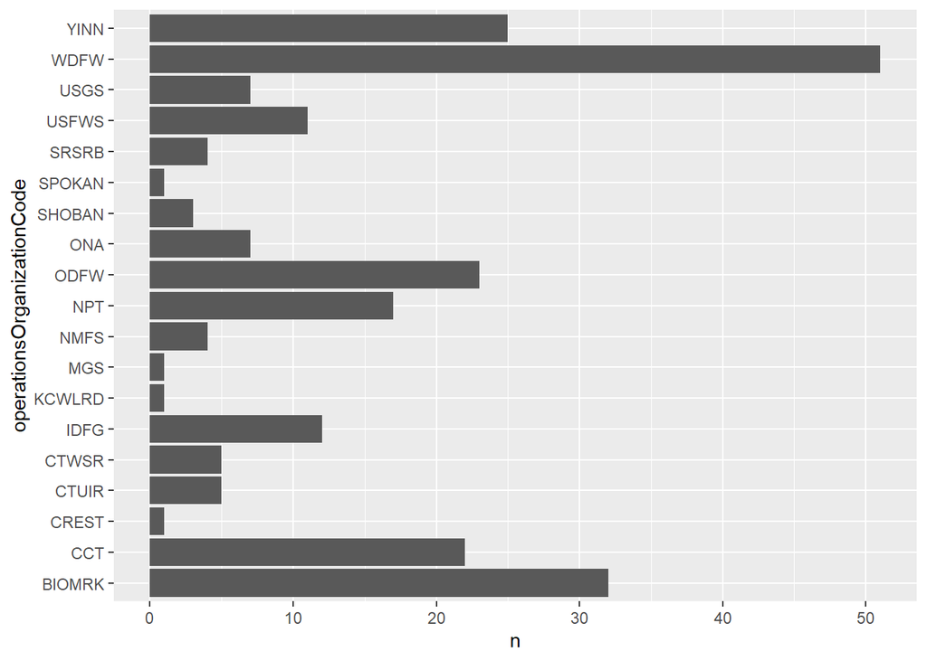

```r
# count active instream remote sites by organization
int_meta %>%
  filter(siteType == "Instream Remote Detection System",
         active) %>%
  count(operationsOrganizationCode) %>%
  ggplot(aes(x = operationsOrganizationCode, y = n)) +
    geom_col() +
    coord_flip()
```

Or, we can use the `int_meta` object to map our interrogation sites using the `sf` package. State polygons are available from the `maps` package.

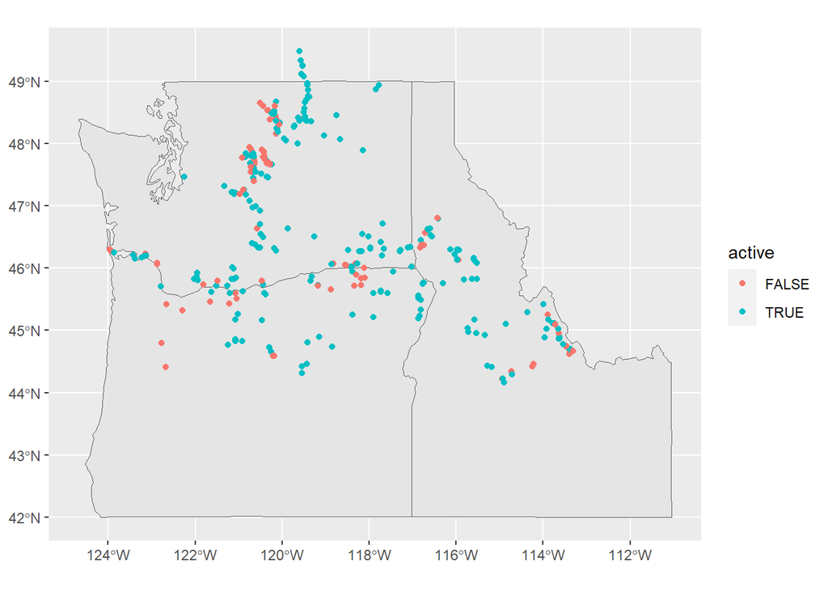

```r
# plot location of interrogation sites
#install.packages('maps')

# get state boundaries
pnw = st_as_sf(maps::map("state",
                   region = c('ID', 'WA', 'OR'),
                   plot = FALSE,
                   fill = TRUE)) # get state boundaries

# create spatial feature object of IPTDS
int_sf <- int_meta %>%
  filter(siteType == "Instream Remote Detection System",
         !is.na(longitude),
         !is.na(latitude)) %>%
  st_as_sf(coords = c('longitude', 'latitude'),
           crs = 4326) # WGS84

ggplot() +
  geom_sf(data = pnw) +
  geom_sf(data = int_sf, aes(color = active))
```

`PITcleanr` also includes the `queryInterrogationConfig()` function to query and download configuration metadata for PTAGIS interrogation sites. The configuration metadata contains information about individual antennas, transceivers, and their arrangement across time. Similar to above, `site_code` can be set to `NULL` to get configuration metadata for all PTAGIS interrogation sites or you can designate the site of interest.

```r
# configuration of an interrogation site
int_config <- queryInterrogationConfig(site_code = 'ZEN')

int_config %>%
  kable() %>%
  kable_styling(full_width = TRUE,
                bootstrap_options = 'striped')
```

| siteCode | siteName | siteType | configurationSequence | startDate | endDate | isCurrent | antennaGroupName | antennaGroupSortValue | transceiverID | transceiverType | antennaID |
| --- | --- | --- | --- | --- | --- | --- | --- | --- | --- | --- | --- |
| ZEN | Secesh River at Zena Cr. Ranch | Instream | 110 | 2012-04-12 | NA | TRUE | UPPER IN-STREAM ARRAY | A | A0 | FS1001M | A1 |
| ZEN | Secesh River at Zena Cr. Ranch | Instream | 110 | 2012-04-12 | NA | TRUE | UPPER IN-STREAM ARRAY | A | A0 | FS1001M | A2 |
| ZEN | Secesh River at Zena Cr. Ranch | Instream | 110 | 2012-04-12 | NA | TRUE | UPPER IN-STREAM ARRAY | A | A0 | FS1001M | A3 |
| ZEN | Secesh River at Zena Cr. Ranch | Instream | 110 | 2012-04-12 | NA | TRUE | UPPER IN-STREAM ARRAY | A | A0 | FS1001M | A4 |
| ZEN | Secesh River at Zena Cr. Ranch | Instream | 110 | 2012-04-12 | NA | TRUE | LOWER IN-STREAM ARRAY | B | B0 | FS1001M | B1 |
| ZEN | Secesh River at Zena Cr. Ranch | Instream | 110 | 2012-04-12 | NA | TRUE | LOWER IN-STREAM ARRAY | B | B0 | FS1001M | B2 |
| ZEN | Secesh River at Zena Cr. Ranch | Instream | 110 | 2012-04-12 | NA | TRUE | LOWER IN-STREAM ARRAY | B | B0 | FS1001M | B3 |
| ZEN | Secesh River at Zena Cr. Ranch | Instream | 110 | 2012-04-12 | NA | TRUE | LOWER IN-STREAM ARRAY | B | B0 | FS1001M | B4 |
| ZEN | Secesh River at Zena Cr. Ranch | Instream | 110 | 2012-04-12 | NA | TRUE | LOWER IN-STREAM ARRAY | B | B0 | FS1001M | B5 |
| ZEN | Secesh River at Zena Cr. Ranch | Instream | 110 | 2012-04-12 | NA | TRUE | LOWER IN-STREAM ARRAY | B | B0 | FS1001M | B6 |

## 2.2 Mark/Recapture/Recovery Sites

A similar function exists to query and download metadata for PTAGIS mark-recapture-recovery (MRR) sites; however, configuration data doesn’t exist for MRR sites so there is no need for a `queryMRRConfig` function.

```r
# all MRR sites
mrr_meta <- queryMRRMeta(site = NULL)

head(mrr_meta, 3) %>%
  kable() %>%
  kable_styling(full_width = TRUE,
                bootstrap_options = "striped")
```

| siteCode | name | rkm | type | huC8Code | latitude | longitude | coordinateType | legacyType | parentLocation | minKm | maxKm | markSiteOnly | pointLocation | shapeType | streamLocationId | spatialLineId | spatialPolyId | spatialFacId |
| --- | --- | --- | --- | --- | --- | --- | --- | --- | --- | --- | --- | --- | --- | --- | --- | --- | --- | --- |
| 15MILC | Fifteen Mile Creek, near The Dalles, Oregon | 309 | River | 17070105 | 45.48169 | -121.0756 | Midpoint | R |  | 0 | 86 | FALSE | FALSE | line | 1211264456185 | 119 | NA | NA |
| 1890SC | 1890s Side Channel Methow River | 843.067 | River | 17020008 | 48.37819 | -120.1331 | Midpoint | R |  | 0 | 3 | FALSE | FALSE | line | 1201196483692 | 586 | NA | NA |
| 18MILC | Eighteenmile Creek, Lemhi River Basin | 522.303.416.092 | River | 17060204 | 44.52558 | -113.2369 | Midpoint | R |  | 0 | 43 | FALSE | FALSE | line | 1133545446822 | 145 | NA | NA |

## 2.3 All PTAGIS Sites

`PITcleanr` includes additional wrapper functions that can query interrogation and MRR sites together. The `queryPtagisMeta()` function downloads all INT and MRR sites at once. While the `buildConfig()` function goes a step further and downloads all INT and MRR site metadata, plus INT site configuration information, and then applies some formatting to combine all metadata into a single data frame. Additionally, `buildConfig()` creates a `node` field which is a unique location which groups detections by a user defined spatial scale.

```r
# wrapper to download all site meta
# ptagis_meta <- queryPtagisMeta()

# wrapper to download site metadata and INT configuration data at once, and apply some formatting
config <- buildConfig(node_assign = "array",
                      array_suffix = "UD")

# number of unique sites in PTAGIS
n_distinct(config$site_code)
```

```
#> [1] 1858
```

```r
# number of unique nodes in PTAGIS
n_distinct(config$node)
```

```
#> [1] 2111
```

```r
# the number of detection locations/antennas in PTAGIS
nrow(config)
```

```
#> [1] 7308
```

```r
head(config, 9) %>%
  select(-site_description) %>% # remove site_description column for formatting
  kable() %>%
  kable_styling(full_width = TRUE,
                bootstrap_options = "striped")
```

| site_code | config_id | antenna_id | node | start_date | end_date | site_type | site_name | antenna_group | site_type_name | rkm | rkm_total | latitude | longitude |
| --- | --- | --- | --- | --- | --- | --- | --- | --- | --- | --- | --- | --- | --- |
| 0HR | 100 | 01 | 0HR | 2022-07-26 | NA | INT | Henrys Instream Array | Main Array | Instream Remote Detection System | 522.303.416.047 | 1288 | 44.89690 | -113.6247 |
| 0HR | 100 | 02 | 0HR | 2022-07-26 | NA | INT | Henrys Instream Array | Main Array | Instream Remote Detection System | 522.303.416.047 | 1288 | 44.89690 | -113.6247 |
| 0HR | 100 | 03 | 0HR | 2022-07-26 | NA | INT | Henrys Instream Array | Main Array | Instream Remote Detection System | 522.303.416.047 | 1288 | 44.89690 | -113.6247 |
| 158 | 100 | D1 | 158_U | 2011-11-29 | NA | INT | Fifteenmile Ck at Eightmile Ck | Upstream Eightmile Ck | Instream Remote Detection System | 309.004 | 313 | 45.60643 | -121.0863 |
| 158 | 100 | D2 | 158_U | 2011-11-29 | NA | INT | Fifteenmile Ck at Eightmile Ck | Middle Eightmile Ck | Instream Remote Detection System | 309.004 | 313 | 45.60643 | -121.0863 |
| 158 | 100 | D3 | 158_D | 2011-11-29 | NA | INT | Fifteenmile Ck at Eightmile Ck | Downstream Eightmile Ck | Instream Remote Detection System | 309.004 | 313 | 45.60643 | -121.0863 |
| 158 | 100 | D4 | 158_U | 2011-11-29 | NA | INT | Fifteenmile Ck at Eightmile Ck | Upstream Fifteenmile Ck | Instream Remote Detection System | 309.004 | 313 | 45.60643 | -121.0863 |
| 158 | 100 | D5 | 158_U | 2011-11-29 | NA | INT | Fifteenmile Ck at Eightmile Ck | Middle Fifteenmile Ck | Instream Remote Detection System | 309.004 | 313 | 45.60643 | -121.0863 |
| 158 | 100 | D6 | 158_D | 2011-11-29 | NA | INT | Fifteenmile Ck at Eightmile Ck | Downstream Fifteenmile Ck | Instream Remote Detection System | 309.004 | 313 | 45.60643 | -121.0863 |

The `buildConfig()` column includes the arguments `node_assign` and `array_suffix`. The node_assign argument includes the options `c("array", "site", "antenna")` which allows the user to assign PIT tag arrays, entire sites, or individual antennas, respectively, which can then be used as a grouping variable for subsequent data prep and analysis. By default, observations are assigned to individual “array”s, and upstream and downstream arrays are assigned the suffixes “_U” and “_D”, respectively. In the case of 3-span arrays, observations at the middle array are assigned to the upstream array. Play with the different settings and review the output to learn the differences.

```r
tmp_config <- buildConfig(node_assign = "site", #"array", "site", "antenna"
                      array_suffix = "UMD") #"UD", "UMD", "AOBO"
```

## 2.4 Test Tags

To help assess a site’s operational condition `PITcleanr` includes the function `queryTestTagSite()`. The function queries the test tag history from PTAGIS for a single interrogation site during a calendar year. The test tag information is useful to quickly examine the site for operation conditions and to help understand potential assumption violations with future analyses.

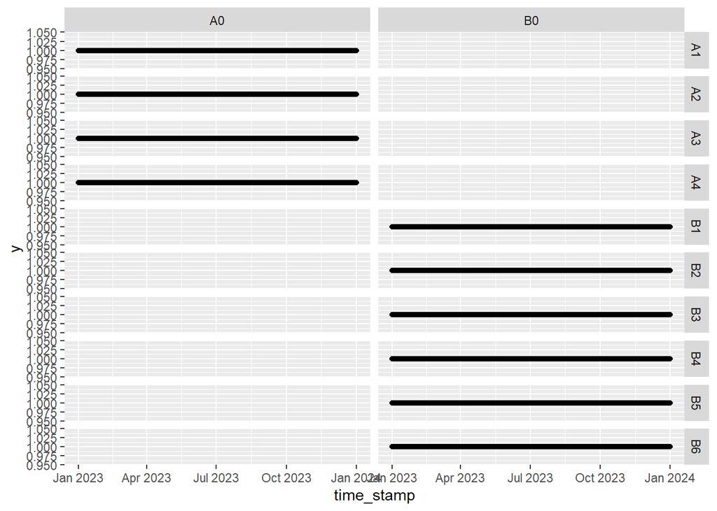

```r
# check for timer tag to evaluate site operation
test_tag = queryTestTagSite(site_code = "ZEN",
                            year = 2023,
                            api_key = api_key)

test_tag %>%
  ggplot(aes(x = time_stamp, y = 1)) +
  geom_point() +
  facet_grid(antenna_id~transceiver_id)
```

# 3 Compressing Tag Observations

## 3.1 PTAGIS Complete Tag Histories

In a typical PIT tag analysis workflow a user starts with a list of tags containing all the codes of interest, and then searches a data repository for all the observations of the listed tags.

### 3.1.1 Tag List

A tag list is typically a .txt file with one row per tag code. For convenience, we’ve included one such file with `PITcleanr`, which contains tag IDs for Chinook salmon adults implanted with tags at Tumwater Dam in 2018. The following can be used to find the path to this example file. Alternatively, the user can provide the file path to their own tag list.

```r
# generate file path to example tag list in PITcleanr
tag_list = system.file("extdata",
                       "TUM_chnk_tags_2018.txt",
                       package = "PITcleanr",
                       mustWork = TRUE)

read_delim(tag_list, delim='\t') %>%
  head(9) %>%
  kable() %>%
  kable_styling(full_width = TRUE,
                bootstrap_options = "striped")
```

| 3DD.00777C5CEC |
| --- |
| 3DD.00777C5E34 |
| 3DD.00777C7728 |
| 3DD.00777C8493 |
| 3DD.00777C9185 |
| 3DD.00777C91C3 |
| 3DD.00777CE6B8 |
| 3DD.00777CEB31 |
| 3DD.00777CEF93 |
| 3DD.00777CEFC1 |

```r
# or simple example to your own file on desktop
#tag_list = "C:/Users/username/Desktop/my_tag_list.txt"
```

### 3.1.2 Read PTAGIS CTH

Once the user has created their own tag list, or located the above example, load the list into PTAGIS to query the complete tag history for each of the listed tags. Detailed instructions for querying complete tag histories for use in PITcleanr can be found [here](https://kevinsee.github.io/PITcleanr/articles/Prep_PIT_data.html). The following fields or attributes are required in the PTAGIS complete tag history query:

- Tag
- Event Site Code
- Event Date Time
- Antenna
- Antenna Group Configuration

Other available PTAGIS fields of interest may also be included. We highly recommended the following fields to help with future summaries:

- Mark Species
- Mark Rear Type
- Event Type
- Event Site Type
- Event Release Site Code
- Event Release Date Time

For convenience, we’ve included an example complete tag history in `PITcleanr` from the above tag list, or you can provide the file path to your own complete tag history.

```r
# file path to the example CTH in PITcleanr
ptagis_file <- system.file("extdata",
                          "TUM_chnk_cth_2018.csv",
                          package = "PITcleanr",
                          mustWork = TRUE)
```

The `PITcleanr` function `readCTH()` is used to read in your complete tag history. Once the data is read by `readCTH()` it then re-formats the column names to be consistent with subsequent PITcleanr functions. In the following example we are only interested in tag observations after the start of the adult run year; so we use the `filter()` function to remove the excess observations.

```r
raw_ptagis = readCTH(ptagis_file,
                     file_type = "PTAGIS") %>%
  # filter for only detections after start of run year
  filter(event_date_time_value >= lubridate::ymd(20180301))

# number of detections
nrow(raw_ptagis)
```

```
#> [1] 13294
```

```r
# number of unique tags
dplyr::n_distinct(raw_ptagis$tag_code)
```

```
#> [1] 1406
```

We can compare the downloaded complete tag history file with the output of the `readCTH` function by looking at the first couple rows of data.

```r
head(raw_ptagis, 4) %>%
  kable() %>%
  kable_styling(full_width = TRUE,
              bootstrap_options = "striped")
```

| tag_code | event_site_code_value | event_date_time_value | antenna_id | antenna_group_configuration_value | mark_species_name | mark_rear_type_name | event_type_name | event_site_type_description | event_release_site_code_code | event_release_date_time_value | cth_count |
| --- | --- | --- | --- | --- | --- | --- | --- | --- | --- | --- | --- |
| 384.3B239AC47B | NAL | 2018-07-01 00:06:16 | 63 | 100 | Chinook | Wild Fish or Natural Production | Observation | Instream Remote Detection System | NA | NA | 1 |
| 384.3B239AC47B | UWE | 2018-06-23 22:03:13 | B2 | 110 | Chinook | Wild Fish or Natural Production | Observation | Instream Remote Detection System | NA | NA | 1 |
| 384.3B239AC47B | BO3 | 2018-05-18 09:36:59 | 18 | 110 | Chinook | Wild Fish or Natural Production | Observation | Adult Fishway | NA | NA | 1 |
| 384.3B239AC47B | BO3 | 2018-05-18 09:37:11 | 16 | 110 | Chinook | Wild Fish or Natural Production | Observation | Adult Fishway | NA | NA | 1 |

```r
head(read_csv(ptagis_file), 4) %>%
  kable() %>%
  kable_styling(full_width = TRUE,
                bootstrap_options = "striped")
```

| Tag Code | Mark Species Name | Mark Rear Type Name | Event Type Name | Event Site Type Description | Event Site Code Value | Event Date Time Value | Antenna ID | Antenna Group Configuration Value | Event Release Site Code Code | Event Release Date Time Value | CTH Count |
| --- | --- | --- | --- | --- | --- | --- | --- | --- | --- | --- | --- |
| 384.3B239AC47B | Chinook | Wild Fish or Natural Production | Mark | River | NASONC | 3/1/2016 10:34:00 AM | NA | 0 | NASONC | 3/4/2016 5:00:00 PM | 1 |
| 384.3B239AC47B | Chinook | Wild Fish or Natural Production | Observation | Instream Remote Detection System | NAL | 7/1/2018 12:06:16 AM | 63 | 100 | NA | NA | 1 |
| 384.3B239AC47B | Chinook | Wild Fish or Natural Production | Observation | Instream Remote Detection System | UWE | 6/23/2018 10:03:13 PM | B2 | 110 | NA | NA | 1 |
| 384.3B239AC47B | Chinook | Wild Fish or Natural Production | Observation | Adult Fishway | BO3 | 5/18/2018 9:36:59 AM | 18 | 110 | NA | NA | 1 |

Note that `readCTH()` includes the argument file_type which can be used to import data from Biomark’s BioLogic (“Biologic_csv”) database or data downloaded directly from a PIT-tag reader, in either a .log or .xlsx format (“raw”). These formats may be useful for smaller studies or studies outside the Columbia River Basin whose data may not be uploaded to PTAGIS.

### 3.1.3 Quality Control

The `qcTagHistory()` function is used to perform basic quality control on PTAGIS detections. Note it can be run on either the file path to the complete tag histories or the data frame returned by `readCTH()`. `qcTagHistory()` provides information on disowned and orphan tags and information on the various release groups included in the detections. More info can be found here.

```r
# using the complete tag history file path
qc_detections = qcTagHistory(ptagis_file)

# or the complete tag history tibble from readCTH()
qc_detections = qcTagHistory(raw_ptagis)

# view QC results
qc_detections
```

```
#> $disown_tags
#> character(0)
#>
#> $orphan_tags
#> character(0)
#>
#> $rel_time_batches
#> # A tibble: 6 × 11
#>   mark_species_name  year event_site_type_description event_type_name
#>   <chr>             <dbl> <chr>                       <chr>
#> 1 Chinook            2018 Dam                         Mark
#> 2 Chinook            2018 Dam                         Recapture
#> 3 Chinook            2018 Intra-Dam Release Site      Mark
#> 4 Chinook            2018 Intra-Dam Release Site      Mark
#> 5 Chinook            2018 Trap or Weir                Recapture
#> 6 Chinook            2018 Trap or Weir                Recapture
#> # ℹ 7 more variables: event_site_code_value <chr>, n_tags <int>,
#> #   n_events <int>, n_release <int>, rel_greq_event <int>, rel_ls_event <int>,
#> #   event_rel_ratio <dbl>
```

```r
qc_detections$rel_time_batches %>%
  kable() %>%
  kable_styling(full_width = TRUE,
                bootstrap_options = "striped")
```

| mark_species_name | year | event_site_type_description | event_type_name | event_site_code_value | n_tags | n_events | n_release | rel_greq_event | rel_ls_event | event_rel_ratio |
| --- | --- | --- | --- | --- | --- | --- | --- | --- | --- | --- |
| Chinook | 2018 | Dam | Mark | TUM | 1350 | 1350 | 1339 | 1350 | 0 | 1.008215 |
| Chinook | 2018 | Dam | Recapture | TUM | 136 | 143 | 142 | 143 | 0 | 1.007042 |
| Chinook | 2018 | Intra-Dam Release Site | Mark | BONAFF | 18 | 12 | 12 | 18 | 0 | 1.000000 |
| Chinook | 2018 | Intra-Dam Release Site | Mark | WELLD2 | 2 | 2 | 2 | 2 | 0 | 1.000000 |
| Chinook | 2018 | Trap or Weir | Recapture | CHIW | 66 | 5 | 5 | 66 | 0 | 1.000000 |
| Chinook | 2018 | Trap or Weir | Recapture | CHIWAT | 11 | 8 | 8 | 12 | 0 | 1.000000 |

### 3.1.4 Single Tag Codes and Marking Files

Often you may be interested in observations for a single tag code. To help with this, `PITcleanr` contains the `queryCapHist()` function to query observations for a single tag from DART’s mirrored data repository of PTAGIS. This function can be helpful if you are interested in a small number of tag codes and want to programmatically develop summaries. The function requires a tag code input and will return observation data post marking.

```r
# query PTAGIS complete tag history for a single tag code; some examples
tagID <- "3D6.1D594D4AFA" # IR3, GOJ, BO1 -> IR5
tagID <- "3DD.003D494091" # GRA, IR1 -> IML

tag_cth = queryCapHist(ptagis_tag_code = tagID)

# example to summarise CTH
tag_cth %>%
  group_by(event_type_name,
           event_site_code_value) %>%
  summarise(n_dets = n(),
            min_det = min(event_date_time_value),
            max_det = max(event_date_time_value)) %>%
  mutate(duration = difftime(max_det, min_det, units = "hours")) %>%
  kable() %>%
  kable_styling(full_width = TRUE,
            bootstrap_options = 'striped')
```

| event_type_name | event_site_code_value | n_dets | min_det | max_det | duration |
| --- | --- | --- | --- | --- | --- |
| Observation | GRA | 11 | 2023-06-08 14:30:48 | 2023-06-08 14:35:48 | 0.0833333 hours |
| Observation | IML | 3 | 2023-07-02 14:42:18 | 2023-07-03 07:16:29 | 16.5697222 hours |
| Observation | IR1 | 1 | 2023-06-13 14:52:29 | 2023-06-13 14:52:29 | 0.0000000 hours |
| Observation | IR2 | 1 | 2023-06-14 15:00:55 | 2023-06-14 15:00:55 | 0.0000000 hours |
| Observation | IR3 | 4 | 2023-06-24 10:24:12 | 2023-06-24 10:27:44 | 0.0588889 hours |
| Observation | IR4 | 8 | 2023-07-01 18:50:12 | 2023-07-01 19:49:50 | 0.9938889 hours |
| Recapture | IMNAHW | 1 | 2023-07-03 10:00:00 | 2023-07-03 10:00:00 | 0.0000000 hours |

DART no longer provides mark event information with a tag code’s observation data. If the marking information is necessary you can change the argument `include_mark` to TRUE to also query the PTAGIS marking record. Note: including the mark record requires a PTAGIS “API Key” which can be requested from the [PTAGIS API website](https://www.ptagis.org/Content/DataSpecification/index.htm?context=160).

```r
cth_node <- queryCapHist(ptagis_tag_code = tagID,
                         config = config,
                         include_mark = TRUE,
                         api_key = api_key)
```

Additionally, the `queryMRRDataFile()` function can be used to query a raw MRR file from PTAGIS. NOTE: only the latest corrected version of a MRR file is returned.

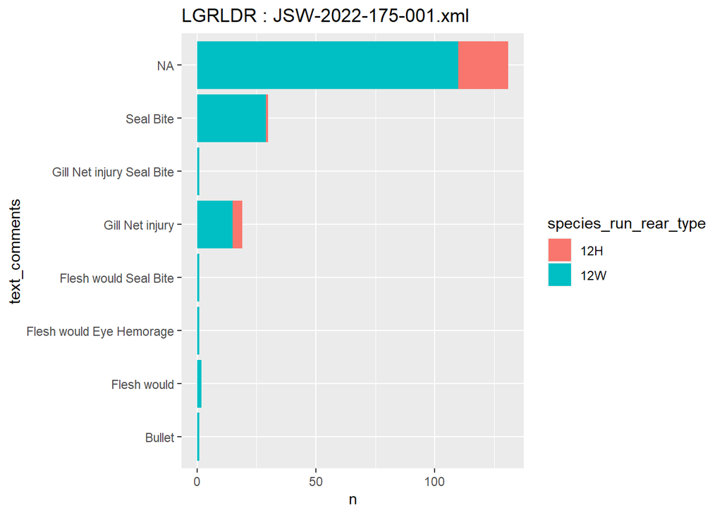

```r
# MRR tag file summaries
#mrr_file <- "NBD15065.TUM"
mrr_file <- "JSW-2022-175-001.xml"

mrr_data <- queryMRRDataFile(mrr_file)

# summary of injuries
mrr_data %>%
  group_by(species_run_rear_type, text_comments) %>%
  count() %>%
  ggplot(aes(x = text_comments, y = n, fill = species_run_rear_type)) +
  geom_col() +
  coord_flip() +
  labs(title = paste0(unique(mrr_data$release_site), ' : ', mrr_file))
```

If more than one mark file is desired the user could iterate over `queryMRRDataFile()` to easily query multiple files and combine them into a single data frame or list.

```r
julian = str_pad(1:10, 3, pad = 0) # julian 001 - 010
yr = 2024                          # tagging year

# Imnaha smolt trap, first 10 days of 2024
mrr_files = paste0("IMN-", yr, "-", julian, "-NT1.xml")

mrr_data <- map_df(mrr_files,  # loop across files
             .f = queryMRRDataFile)

# view mrr data
mrr_data
```

```
#> # A tibble: 20 × 24
#>    capture_method event_date          event_site event_type life_stage
#>    <chr>          <dttm>              <chr>      <chr>      <chr>
#>  1 SCREWT         2024-01-01 20:00:00 IMNTRP     Tally      Juvenile
#>  2 SCREWT         2024-01-02 20:00:00 IMNTRP     Tally      Juvenile
#>  3 SCREWT         2024-01-03 16:59:12 IMNTRP     Mark       Juvenile
#>  4 SCREWT         2024-01-04 16:01:40 IMNTRP     Tally      Juvenile
#>  5 SCREWT         2024-01-04 16:04:06 IMNTRP     Mark       Juvenile
#>  6 SCREWT         2024-01-04 16:05:10 IMNTRP     Mark       Juvenile
#>  7 SCREWT         2024-01-05 16:23:43 IMNTRP     Tally      Juvenile
#>  8 SCREWT         2024-01-05 16:24:47 IMNTRP     Mark       Juvenile
#>  9 SCREWT         2024-01-05 16:25:04 IMNTRP     Mark       Juvenile
#> 10 SCREWT         2024-01-06 20:00:00 IMNTRP     Tally      Juvenile
#> 11 SCREWT         2024-01-07 20:00:00 IMNTRP     Tally      Juvenile
#> 12 SCREWT         2024-01-08 15:54:03 IMNTRP     Mark       Juvenile
#> 13 SCREWT         2024-01-08 15:56:50 IMNTRP     Mark       Juvenile
#> 14 SCREWT         2024-01-08 15:57:03 IMNTRP     Mark       Juvenile
#> 15 SCREWT         2024-01-08 15:57:18 IMNTRP     Mark       Juvenile
#> 16 SCREWT         2024-01-08 15:57:33 IMNTRP     Mark       Juvenile
#> 17 SCREWT         2024-01-09 20:00:00 IMNTRP     Tally      Juvenile
#> 18 SCREWT         2024-01-10 15:57:39 IMNTRP     Mark       Juvenile
#> 19 SCREWT         2024-01-10 15:58:36 IMNTRP     Mark       Juvenile
#> 20 SCREWT         2024-01-10 15:59:01 IMNTRP     Tally      Juvenile
#> # ℹ 19 more variables: mark_method <chr>, migration_year <chr>,
#> #   organization <chr>, pit_tag <chr>, release_date <dttm>, release_site <chr>,
#> #   sequence_number <dbl>, species_run_rear_type <chr>, tagger <chr>,
#> #   n_fish <chr>, brood_year <chr>, length <dbl>, location_source <chr>,
#> #   location_latitude <chr>, location_longitude <chr>, mark_temperature <chr>,
#> #   release_temperature <chr>, weight <chr>, text_comments <chr>
```

```r
# summarise new marks by day
mrr_data %>%
  filter(event_type == 'Mark') %>%
  mutate(release_date = date(release_date)) %>%
  group_by(release_date,
           species_run_rear_type) %>%
  count() %>%
  kable() %>%
  kable_styling(full_width = TRUE,
                bootstrap_options = "striped")
```

| release_date | species_run_rear_type | n |
| --- | --- | --- |
| 2024-01-04 | 12W | 1 |
| 2024-01-05 | 12W | 2 |
| 2024-01-06 | 12W | 2 |
| 2024-01-09 | 12W | 5 |
| 2024-01-11 | 12W | 2 |

The mark data from `queryMRRDataFile()` and the observations data from `queryCapHist()` could also be combined to form a complete tag history. However, this process is not recommended for large number of tag codes.

## 3.2 Compress Detections

After downloading the complete tag history data from PTAGIS and reading the file into the R environment with `readCTH` we are now ready to start summarizing the information. The first step is to `compress` the tag histories into a more manageable format based on the “array” configuration from above step using the function `buildConfg` and the argument `node_assign`.

```r
# compress observations
comp_obs = compress(raw_ptagis,
                    configuration = config)

# view compressed observations
head(comp_obs)
```

```
#> # A tibble: 6 × 9
#>   tag_code       node   slot event_type_name n_dets min_det
#>   <chr>          <chr> <int> <chr>            <int> <dttm>
#> 1 384.3B239AC47B BO3       1 Observation         18 2018-05-18 09:36:59
#> 2 384.3B239AC47B BO4       2 Observation          7 2018-05-18 13:03:11
#> 3 384.3B239AC47B TD1       3 Observation          4 2018-05-20 17:20:39
#> 4 384.3B239AC47B JO1       4 Observation          2 2018-05-21 17:49:21
#> 5 384.3B239AC47B MC2       5 Observation         12 2018-05-24 09:04:38
#> 6 384.3B239AC47B PRA       6 Observation          4 2018-05-28 13:58:51
#> # ℹ 3 more variables: max_det <dttm>, duration <drtn>, travel_time <drtn>
```

```r
# compare number of directions
nrow(raw_ptagis)
```

```
#> [1] 13294
```

```r
nrow(comp_obs)
```

```
#> [1] 6755
```

The result of `compress` can easily be summarized for unique tags at each node.

```r
n_distinct(comp_obs$tag_code)
```

```
#> [1] 1406
```

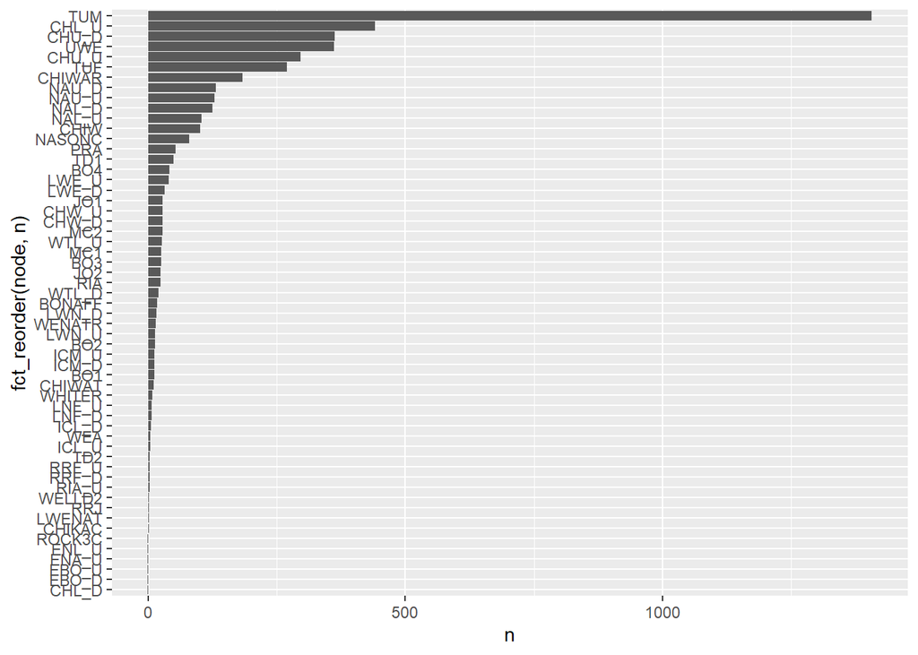

```r
comp_obs %>%
  group_by(node) %>%
  summarise(n = n_distinct(tag_code)) %>%
  ggplot(aes(x = fct_reorder(node,n), y = n)) +
  geom_col() +
  coord_flip()
```

# 4 Fish Pathways

## 4.1 Parent-Child Tables

The next logical step in a PIT-tag analysis is to order the nodes, or observation points, by their location along a stream network. Ordering observations is completed with a “parent-child” table. But first we need to extract the sites of interest and place them on the stream using the lat/long data stored in PTAGIS.

```r
# extract sites from complete tag histories
sites_sf = extractSites(raw_ptagis,
                        as_sf = T,
                        min_date = '20180301',
                        configuration = config)
```

```r
sites_sf = sites_sf %>%
  # all sites in Wenatchee and having an rkm greater than or equal to 754
  filter(str_detect(rkm, '^754'),
         type != "MRR",
         site_code != 'LWE') %>%
  mutate(across(site_code,
                ~ recode(.,
                         "TUF" = "TUM")))
```

The next step is to download the stream spatial layer from the USGS and the [National Hydrography Dataset](https://www.usgs.gov/national-hydrography/national-hydrography-dataset). The stream layer is downloaded using the `queryFlowlines()` function and is structured as a list that needs to be converted into an `sf` object.

```r
nhd_list = queryFlowlines(sites_sf = sites_sf,
                          root_site_code = "TUM",
                          min_strm_order = 2,
                          dwnstrm_sites = T,
                          dwn_min_stream_order_diff = 2)
```

```
#> Querying streams upstream of TUM
#> Calculating furthest mainstem point downstream
#> Querying streams downstream of TUM
```

```r
# join upstream and downstream flowlines in nhd_list
flowlines = nhd_list$flowlines %>%
    rbind(nhd_list$dwn_flowlines)
```

You can now build a simple map of your site locations and how they relate to each other across the stream network.

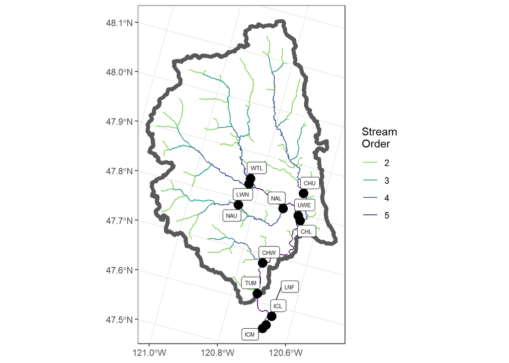

```r
# load ggplot
library(ggplot2)

tum_map <- ggplot() +
  geom_sf(data = flowlines,
          aes(color = as.factor(StreamOrde),
              size = StreamOrde)) +
  scale_color_viridis_d(direction = -1,
                        option = "D",
                        name = "Stream\nOrder",
                        end = 0.8) +
  scale_size_continuous(range = c(0.2, 1.2),
                        guide = 'none') +
  geom_sf(data = nhd_list$basin,
          fill = NA,
          lwd = 2) +
  theme_bw() +
  theme(axis.title = element_blank())

tum_map +
  geom_sf(data = sites_sf,
          size = 4,
          color = "black") +
  ggrepel::geom_label_repel(
    data = sites_sf,
    aes(label = site_code,
        geometry = geometry),
    size = 2,
    stat = "sf_coordinates",
    min.segment.length = 0,
    max.overlaps = 50
  )
```

We can now construct the parent-child table to continue processing the PIT-tag data using `buildParentChild()`.

```r
# build parent-child table
parent_child = buildParentChild(sites_sf,
                                flowlines)
```

After we build the parent-child table from our complete tag history data and the extracted sites we recommend plotting the nodes to double check all the necessary locations are included. The relationship of nodes to each other can be easily plotted with the `plotNodes()` function.

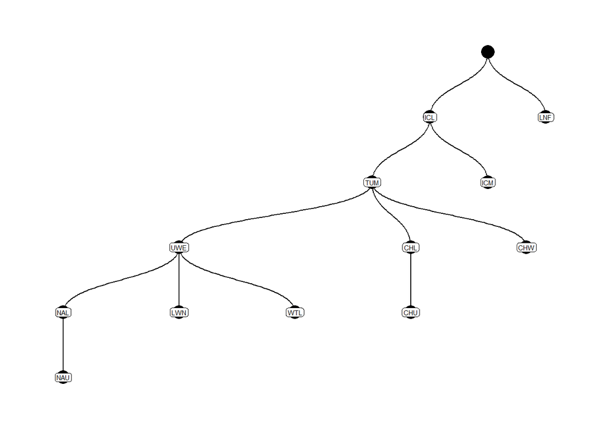

```r
# plot parent-child table
plotNodes(parent_child)
```

If errors in the parent-child table exist they can be edited using the `editParentChild()` function. More details regarding these functions can be found [here](https://kevinsee.github.io/PITcleanr/articles/parent_child.html).

```r
# edit parent-child table
parent_child = editParentChild(parent_child,
                               fix_list = list(c(NA, "PES", "TUM"),
                                               c(NA, "LNF", "ICL"),
                                               c("PES", "ICL", "TUM")),
                               switch_parent_child = list(c("ICL", 'TUM'))) %>%
  filter(!is.na(parent))
```

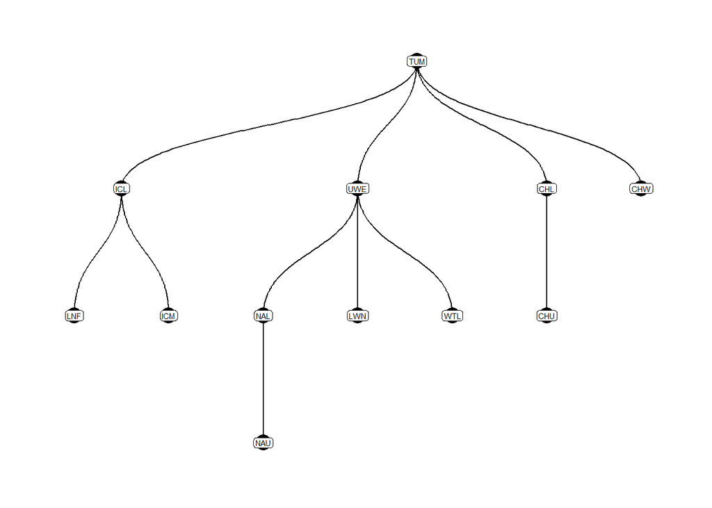

```r
# plot new parent-child table
plotNodes(parent_child)
```

### 4.1.1 Add Nodes (Arrays)

If the configuration file contains multiple nodes for some sites (e.g., a node for each array at a site), then the parent-child table can be expanded to accommodate these nodes using the addParentChildNodes() function.

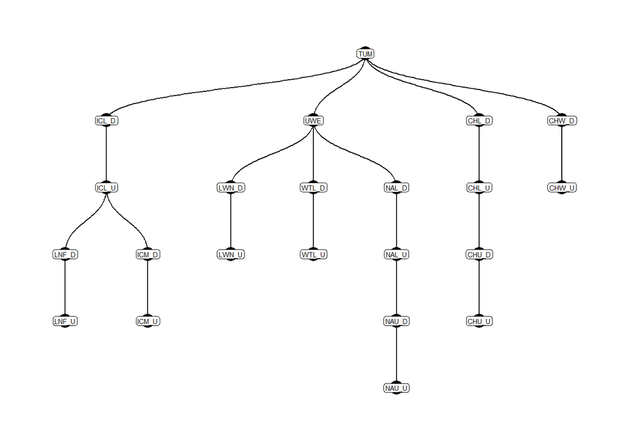

```r
# add nodes for arrays
parent_child_nodes = addParentChildNodes(parent_child = parent_child,
                                        configuration = config)

# plot parent-child w/ nodes
plotNodes(parent_child_nodes)
```

## 4.2 Movement Paths

`PITcleanr` provides a two functions to determine the detection locations a tag would pass between a starting point (e.g, a tagging or release location) and an ending point (e.g., each subsequent detection point), based on the parent-child table. We refer to these detection locations as a movement path. They are equivalent to following one of the paths in the figures above. The `buildPaths` function creates the path, and `buildNodeOrder` assigns the nodes’s order in the pathway. Each of these functions currently has an argument, direction that provides paths and node orders based on upstream movement (the default) or downstream movement. For downstream movement, each node may appear in the resulting tibble multiple times, as there may be multiple ways to reach that node, from different starting points.

```r
# build paths and add node order
node_order = buildNodeOrder(parent_child = parent_child_nodes)

# view node paths and orders
node_order %>%
  arrange(node) %>%
  kable() %>%
  kable_styling(full_width = TRUE,
                bootstrap_options = "striped")
```

| node | node_order | path |
| --- | --- | --- |
| CHL_D | 2 | TUM CHL_D |
| CHL_U | 3 | TUM CHL_D CHL_U |
| CHU_D | 4 | TUM CHL_D CHL_U CHU_D |
| CHU_U | 5 | TUM CHL_D CHL_U CHU_D CHU_U |
| CHW_D | 2 | TUM CHW_D |
| CHW_U | 3 | TUM CHW_D CHW_U |
| ICL_D | 2 | TUM ICL_D |
| ICL_U | 3 | TUM ICL_D ICL_U |
| ICM_D | 4 | TUM ICL_D ICL_U ICM_D |
| ICM_U | 5 | TUM ICL_D ICL_U ICM_D ICM_U |
| LNF_D | 4 | TUM ICL_D ICL_U LNF_D |
| LNF_U | 5 | TUM ICL_D ICL_U LNF_D LNF_U |
| LWN_D | 3 | TUM UWE LWN_D |
| LWN_U | 4 | TUM UWE LWN_D LWN_U |
| NAL_D | 3 | TUM UWE NAL_D |
| NAL_U | 4 | TUM UWE NAL_D NAL_U |
| NAU_D | 5 | TUM UWE NAL_D NAL_U NAU_D |
| NAU_U | 6 | TUM UWE NAL_D NAL_U NAU_D NAU_U |
| TUM | 1 | TUM |
| UWE | 2 | TUM UWE |
| WTL_D | 3 | TUM UWE WTL_D |
| WTL_U | 4 | TUM UWE WTL_D WTL_U |

## 4.3 Travel Direction

With the parent-child relationships established, `PITcleanr` can assign a direction between each node where a given tag was detected.

```r
# add direction based on parent-child table
comp_dir <- addDirection(compress_obs = comp_obs,
                         parent_child = parent_child_nodes,
                         direction = "u")

head(comp_dir, 6) %>%
  kable() %>%
  kable_styling(full_width = TRUE,
                bootstrap_options = "striped")
```

| tag_code | node | slot | event_type_name | n_dets | min_det | max_det | duration | travel_time | node_order | path | direction |
| --- | --- | --- | --- | --- | --- | --- | --- | --- | --- | --- | --- |
| 384.3B239AC47B | TUM | 9 | Recapture | 1 | 2018-06-16 15:26:31 | 2018-06-16 15:26:31 | 0 mins | 184.0167 mins | 1 | TUM | start |
| 384.3B239AC47B | UWE | 10 | Observation | 1 | 2018-06-23 22:03:13 | 2018-06-23 22:03:13 | 0 mins | 10476.7000 mins | 2 | TUM UWE | forward |
| 384.3B239AC47B | NAL_U | 11 | Observation | 1 | 2018-07-01 00:06:16 | 2018-07-01 00:06:16 | 0 mins | 10203.0500 mins | 4 | TUM UWE NAL_D NAL_U | forward |
| 3DD.003B9DD720 | TUM | 9 | Recapture | 1 | 2018-06-17 09:39:26 | 2018-06-17 09:39:26 | 0 mins | 216.6500 mins | 1 | TUM | start |
| 3DD.003B9DD725 | TUM | 10 | Recapture | 1 | 2018-06-19 09:33:08 | 2018-06-19 09:33:08 | 0 mins | 722.4167 mins | 1 | TUM | start |
| 3DD.003B9DD725 | CHU_U | 11 | Observation | 1 | 2018-06-28 21:34:58 | 2018-06-28 21:34:58 | 0 mins | 13681.8333 mins | 5 | TUM CHL_D CHL_U CHU_D CHU_U | forward |

## 4.4 Filter Detections

For some types of analyses, such as Cormack-Jolly-Seber (CJS) models, one of the assumptions is that a tag/individual undergoes only one-way travel (i.e., travel is either all upstream or all downstream). To meet this assumption, individual detections sometimes need to be discarded. For example, an adult salmon undergoing an upstream spawning migration may move up into the Icicle Creek branch of our node network, and then later move back downstream and up another tributary to their final spawning location. In this case, any detections that occurred in Icicle Creek would need to be discarded.

`PITcleanr` contains a function, `filterDetections()`, to help determine which tags/individuals fail to meet the one-way travel assumption and need to be examined further. `filterDetections()` first runs `addDirection()` from above, and then adds two columns, `auto_keep_obs` and `user_keep_obs`. These are meant to indicate whether each row should be kept (i.e. marked TRUE) or deleted (i.e. marked FALSE). For tags that do meet the one-way travel assumption, both auto_keep_obs and user_keep_obs columns will be filled. And if a fish moves back and forth along the same path, `PITcleanr` will indicate that only the last detection at each node should be kept.

If a tag fails to to meet that assumption (e.g. at least one direction is unknown), the `user_keep_obs` column will be NA for all observations of that tag. The `auto_keep_obs` column is `PITcleanr`’s best guess as to which detections should be kept. This guess is based on the assumption that the last and furthest forward-moving detection should be kept, and all detections along that movement path should be kept, while dropping others.

```r
# add direction, and filter detections
comp_filter = filterDetections(compress_obs = comp_obs,
                               parent_child = parent_child_nodes,
                               max_obs_date = "20180930")

# view filtered observations
comp_filter %>%
  select(tag_code:min_det,
         direction,
         ends_with("keep_obs")) %>%
  filter(is.na(user_keep_obs)) %>%
  filter(tag_code == tag_code[1]) %>%
  kable() %>%
  kable_styling(full_width = T,
                bootstrap_options = "striped")
```

| tag_code | node | slot | event_type_name | n_dets | min_det | direction | auto_keep_obs | user_keep_obs |
| --- | --- | --- | --- | --- | --- | --- | --- | --- |
| 3DD.003BC80D81 | TUM | 8 | Recapture | 1 | 2018-06-21 16:14:26 | start | TRUE | NA |
| 3DD.003BC80D81 | UWE | 9 | Observation | 1 | 2018-06-29 15:29:19 | forward | FALSE | NA |
| 3DD.003BC80D81 | NAL_D | 10 | Observation | 1 | 2018-06-30 01:35:27 | forward | FALSE | NA |
| 3DD.003BC80D81 | NAL_U | 11 | Observation | 1 | 2018-06-30 01:35:48 | forward | FALSE | NA |
| 3DD.003BC80D81 | LWN_U | 12 | Observation | 1 | 2018-07-05 23:05:02 | unknown | FALSE | NA |
| 3DD.003BC80D81 | NAL_D | 13 | Observation | 1 | 2018-07-08 03:06:42 | unknown | TRUE | NA |
| 3DD.003BC80D81 | UWE | 14 | Observation | 1 | 2018-07-17 21:52:42 | backward | TRUE | NA |
| 3DD.003BC80D81 | NAL_U | 15 | Observation | 1 | 2018-07-20 21:50:13 | forward | TRUE | NA |
| 3DD.003BC80D81 | NAU_D | 16 | Observation | 1 | 2018-07-30 22:40:06 | forward | TRUE | NA |
| 3DD.003BC80D81 | NAU_U | 17 | Observation | 1 | 2018-07-30 22:41:59 | forward | TRUE | NA |

The user can then save the output from `filterDetections()`, and fill in all the blanks in the `user_keep_obs` column. The `auto_keep_obs` column is merely a suggestion from `PITcleanr`, the user should use their own knowledge of the landscape, where the detection sites are, the run timing and general spatial patterns of that population to make final decisions. Once all the blank user_keep_obs cells have been filled in, that output can be read back into R and filtered for when `user_keep_obs == TRUE`, and the analysis can proceed from there.

Below, we move forward trusting `PITcleanr`’s algorithm.

```r
# after double-checking PITcleanr calls, filter out the final dataset for further analysis
comp_final = comp_filter %>%
  filter(auto_keep_obs = TRUE)
```

```r
# number of unique tags per node
node_tags = comp_final %>%
  group_by(node) %>%
  summarise(n_tags = n_distinct(tag_code))

# view tags per node
node_tags
```

```
#> # A tibble: 22 × 2
#>    node  n_tags
#>    <chr>  <int>
#>  1 CHL_D      1
#>  2 CHL_U    441
#>  3 CHU_D    363
#>  4 CHU_U    297
#>  5 CHW_D     29
#>  6 CHW_U     29
#>  7 ICL_D      6
#>  8 ICL_U      4
#>  9 ICM_D     12
#> 10 ICM_U     12
#> # ℹ 12 more rows
```

## 4.5 Detection Efficiencies

Generally we want to use the number of tags detected as a surrogate to all fish passing the site; however, the detection efficiencies at instream PIT tag arrays is often vary different. To understand detection efficiency difference across sites, and to quickly expand observed tags into estimated tags passing the site `PITcleanr` offers a quick solution. `estNodeEff` uses the corrected observations and node pathways to estimate efficiencies.

```r
# estimate detection efficiencies for nodes
node_eff = estNodeEff(capHist_proc = comp_final,
                      node_order = node_order)
```

```
#> If no node is supplied, calculated for all nodes
```

```r
# view node efficiencies
node_eff
```

```
#> # A tibble: 22 × 8
#>    node  tags_at_node tags_above_node tags_resighted est_tags_at_node
#>    <chr>        <int>           <int>          <int>            <dbl>
#>  1 TUM           1406            1039           1039             1406
#>  2 CHL_D            1             730              1              730
#>  3 CHL_U          441             455            166             1206
#>  4 CHU_D          363             297            206              523
#>  5 CHU_U          297             363            206              523
#>  6 CHW_D           29              29             29               29
#>  7 CHW_U           29              29             29               29
#>  8 ICL_D            6              23              4               33
#>  9 ICL_U            4              25              4               25
#> 10 ICM_D           12              12             11               13
#> # ℹ 12 more rows
#> # ℹ 3 more variables: est_tags_se <dbl>, eff_est <dbl>, eff_se <dbl>
```

## 4.6 Capture Histories

Finally, various mark-recapture models require a capture history of 1’s and 0’s as inputs. `PITcleanr` contains two functions that can help convert tag observations into capture history matrices. `buildCapHist()` uses the compressed observations (whether they’ve been through `filterDections()` or not) and converts them into capture history matrix that can be used in various R survival packages (e.g., Mark). One key will be to ensure the nodes or sites are put in correct order for the user.

```r
# build capture histories
cap_hist = buildCapHist(filter_ch = comp_filter,
                        parent_child = parent_child,
                        configuration = config)

# view capture histories
cap_hist
```

```
#> # A tibble: 1,406 × 2
#>    tag_code       cap_hist
#>    <chr>          <chr>
#>  1 384.3B239AC47B 1000000000000100010000
#>  2 3DD.003B9DD720 1000000000000000000000
#>  3 3DD.003B9DD725 1000100000000000000000
#>  4 3DD.003B9DDAB0 1000000000000000000000
#>  5 3DD.003B9F123C 1000000000000100000000
#>  6 3DD.003BC7A654 1000000000000100101100
#>  7 3DD.003BC7F0E3 1000000000000100101100
#>  8 3DD.003BC80A3C 1000000000000100010000
#>  9 3DD.003BC80D81 1000000000000100111100
#> 10 3DD.003BC80F20 1000000000000000100000
#> # ℹ 1,396 more rows
```

While the `defineCapHistCols()` function identifies the site or node associated with the position of each 1 and 0.

```r
col_nodes <- defineCapHistCols(parent_child = parent_child,
                               configuration = config,
                               use_rkm = T)

col_nodes
```

```
#>  [1] "TUM"   "ICL_D" "ICL_U" "LNF_D" "LNF_U" "ICM_D" "ICM_U" "CHW_D" "CHW_U"
#> [10] "CHL_D" "CHL_U" "CHU_D" "CHU_U" "UWE"   "NAL_D" "NAL_U" "NAU_D" "NAU_U"
#> [19] "WTL_D" "WTL_U" "LWN_D" "LWN_U"
```

```r
rm(list = ls())
```

# 5 Example: Estimate Lemhi Survival

We start by reading in the detection or capture histories that we’ve queried from PTAGIS.

```r
# read in PTAGIS detections
ptagis_file <- system.file("extdata",
                           "LEMTRP_chnk_cth_2021.csv",
                           package = "PITcleanr",
                           mustWork = TRUE)

ptagis_cth <- readCTH(ptagis_file) |>
  arrange(tag_code,
          event_date_time_value)

# qcTagHistory(ptagis_cth,
#              ignore_event_vs_release = T)
```

The configuration file we will use starts with the standard PTAGIS configuration information. For this example we will not concern ourselves with various arrays or antennas at individual sites, but instead we define nodes by their site codes. The first of two exceptions is any sites downstream of Bonneville Dam (river kilometer 234). Because our CJS model will only extend downstream to Bonneville, we will combine all detections below Bonneville with detections at Bonneville, using site B2J. The other exception is to combine the spillway arrays at Lower Granite Dam (site code “GRS”) with other juvenile bypass antennas (“GRJ”) there, because we are not interested in how fish pass Lower Granite dam, only if they do and are detected somewhere while doing so.

```r
configuration <-
  buildConfig(node_assign = "site") |>
   mutate(across(node,
                ~ if_else(as.numeric(str_sub(rkm, 1, 3)) <= 234,
                          "B2J",
                          .)),
         across(node,
                ~ if_else(site_code == "GRS",
                          "GRJ",
                          .))) |>
  filter(!is.na(node))
```

## 5.1 Compress

With the capture histories and a configuration file that shows what node each detection is mapped onto, we can compress those capture histories into a more manageable and meaningful object. For more detail about compressing, see the [Compressing](https://kevinsee.github.io/PITcleanr/articles/compress_data.html) data vignette.

```r
# compress detections
comp_obs <-
  compress(ptagis_cth,
           configuration = configuration,
           units = "days")
```

|  | tag_code | node | slot | event_type_name | n_dets | min_det | max_det | duration | travel_time |
| --- | --- | --- | --- | --- | --- | --- | --- | --- | --- |
| 1 | 384.1B79730415 | LEMTRP | 1 | Mark | 1 | 2022-04-26T09:54:00Z | 2022-04-26T09:54:00Z | 0 |  |
| 2 | 384.1B79730415 | LRW | 2 | Observation | 2 | 2022-04-26T17:15:00Z | 2022-04-26T17:15:00Z | 0 | 0.306 |
| 3 | 384.1B79730415 | LEMTRP | 3 | Recapture | 1 | 2022-04-27T10:09:00Z | 2022-04-27T10:09:00Z | 0 | 0.704 |
| 4 | 384.1B79730415 | HYC | 4 | Observation | 2 | 2022-07-13T23:24:00Z | 2022-07-13T23:25:00Z | 0.001 | 77.552 |
| 5 | 384.1B7973117F | LEMTRP | 1 | Mark | 1 | 2022-04-27T09:59:00Z | 2022-04-27T09:59:00Z | 0 |  |
| 6 | 384.1B7973117F | LRW | 2 | Observation | 1 | 2022-04-27T20:15:00Z | 2022-04-27T20:15:00Z | 0 | 0.428 |
| 7 | 384.1B7973117F | 0HR | 3 | Observation | 1 | 2023-06-20T09:25:00Z | 2023-06-20T09:25:00Z | 0 | 418.549 |
| 8 | 3D9.1C2DEF3A60 | HAYDNC | 1 | Mark | 1 | 2020-09-24T11:56:00Z | 2020-09-24T11:56:00Z | 0 |  |
| 9 | 3D9.1C2DEF3A60 | HYC | 2 | Observation | 1 | 2021-08-20T22:11:00Z | 2021-08-20T22:11:00Z | 0 | 330.427 |
| 10 | 3D9.1C2DEF3A60 | LEMTRP | 3 | Recapture | 1 | 2021-08-21T06:43:00Z | 2021-08-21T06:43:00Z | 0 | 0.356 |

[output cut: 12245 more lines]

## 5.2 Build Parent-Child Table

Based on the complete tag histories from PTAGIS, and our slightly modified configuration file, we will determine which sites to include in our CJS model. The function `extractSites` in the `PITcleanr` package will pull out all the nodes where any of our tags were detected and has the ability to turn that into a spatial object (i.e. an `sf` object) using the latitude and longitude information in the configuration file.

```r
sites_sf <-
  extractSites(ptagis_cth,
               as_sf = T,
               configuration = configuration,
               max_date = "20220630") |>
  arrange(desc(rkm))

sites_sf
```

```
#> Simple feature collection with 26 features and 7 fields
#> Geometry type: POINT
#> Dimension:     XY
#> Bounding box:  xmin: -2000140 ymin: 2523078 xmax: -1366605 ymax: 2823989
#> Projected CRS: NAD83 / Conus Albers
#> # A tibble: 26 × 8
#>    site_code site_name          site_type type  rkm   site_description node_site
#>    <chr>     <chr>              <chr>     <chr> <chr> <chr>            <chr>
#>  1 BTL       Lower Big Timber,… Instream… INT   522.… In-stream detec… BTL
#>  2 BTIMBC    Big Timber Creek,… <NA>      MRR   522.… River            BTIMBC
#>  3 LLS       Lemhi Little Spri… Instream… INT   522.… In-stream detec… LLS
#>  4 LLSPRC    Lemhi Little Spri… <NA>      MRR   522.… River            LLSPRC
#>  5 LRW       Lemhi River Weir   Instream… INT   522.… This is an in-s… LRW
#>  6 HYC       Hayden Creek In-s… Instream… INT   522.… This is an inst… HYC
#>  7 HYDTRP    Hayden Creek Rota… <NA>      MRR   522.… TraporWeir       HYDTRP
#>  8 LEMTRP    Upper Lemhi River… <NA>      MRR   522.… TraporWeir       LEMTRP
#>  9 HAYDNC    Hayden Creek, Lem… <NA>      MRR   522.… River            HAYDNC
#> 10 KEN       Kenney Creek In-s… Instream… INT   522.… In-stream detec… KEN
#> # ℹ 16 more rows
#> # ℹ 1 more variable: geometry <POINT [m]>
```

There are a few screwtraps on the mainstem Salmon River or in a tributary to the Salmon that we are not interested in using. We can filter those by only keeping site from Lower Granite downstream, or sites within the Lemhi basin. Some of these sites are on tributaries of the Lemhi River, and we are not interested in keeping those sites (since we don’t anticipate every fish necessarily moving past those sites)

```r
sites_sf <-
  sites_sf |>
  left_join(configuration |>
              select(site_code,
                     rkm_total) |>
              distinct()) |>
  filter(nchar(rkm) <= 7 |
           (str_detect(rkm, "522.303.416") &
              rkm_total <= rkm_total[site_code == "LEMTRP"] &
              nchar(rkm) == 15),
         !site_code %in% c("HAYDNC",
                           "S3A"))
```

From here, we could build a parent-child table by hand ([see the Parent-Child Tables vignette](https://kevinsee.github.io/PITcleanr/articles/parent_child.html)). To build it using some of the functionality of `PITcleanr`, continue below.

Once the sites have been finalized, we query the NHDPlus v2 flowlines from USGS, using the `queryFlowlines` function in `PITcleanr`.

```r
nhd_list = queryFlowlines(sites_sf,
                          root_site_code = "LLR",
                          min_strm_order = 2,
                          dwnstrm_sites = T,
                          dwn_min_stream_order_diff = 4,
                          buffer_dist = units::as_units(10, "km"))
```

```
#> Querying streams upstream of LLR
#> Calculating furthest mainstem point downstream
#> Querying streams downstream of LLR
```

```r
# compile the upstream and downstream flowlines
flowlines = nhd_list$flowlines |>
  rbind(nhd_list$dwn_flowlines)
```

This figure plots the NHDplus flowlines and our sites.

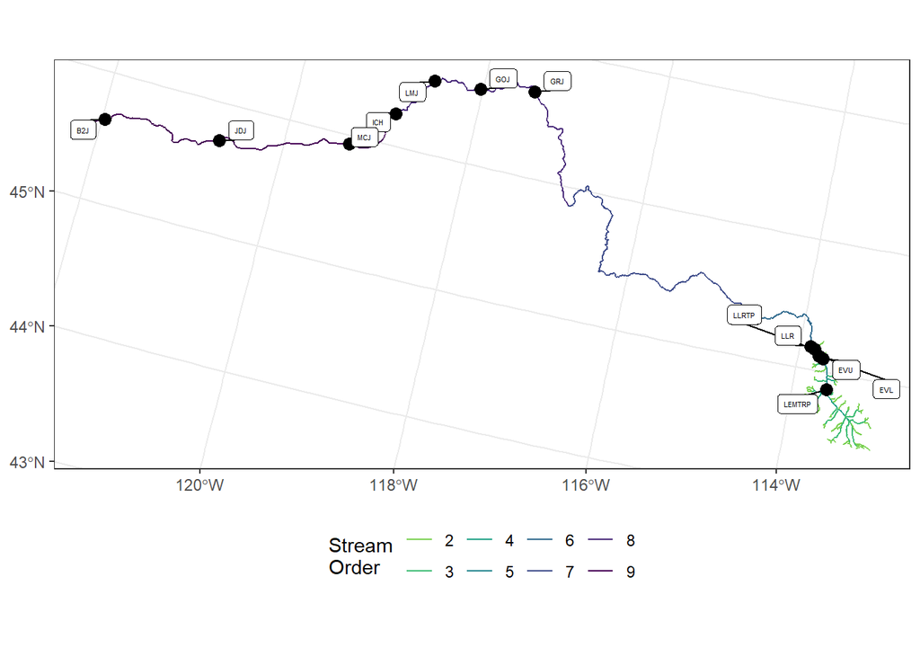

```r
ggplot() +
  geom_sf(data = flowlines,
          aes(color = as.factor(StreamOrde))) +
  scale_color_viridis_d(direction = -1,
                        option = "D",
                        name = "Stream\nOrder",
                        end = 0.8) +
  geom_sf(data = sites_sf,
          size = 3,
          color = "black") +
  ggrepel::geom_label_repel(
    data = sites_sf,
    aes(label = site_code,
        geometry = geometry),
    size = 1.5,
    stat = "sf_coordinates",
    min.segment.length = 0,
    max.overlaps = 100
  ) +
  theme_bw() +
  theme(axis.title = element_blank(),
        legend.position = "bottom")
```

`PITcleanr` can make use of some of the covariates associated with each reach in the NHDPlus_v2 layer to determine which sites are downstream or upstream of one another. This is how we construct the parent-child table, using the `buildParentChild()` function.

```r
# construct parent-child table
parent_child = sites_sf |>
  buildParentChild(flowlines,
                   rm_na_parent = T,
                   add_rkm = F) |>
  select(parent,
         child)
```

```
#> These child locations: B2J,
#>  had no parent location and were removed from the table.
```

By default, `PITcleanr` assumes the parent is downstream of the child. We can switch this direction with some clever coding and renaming.

```r
# flip direction of parent/child relationships
parent_child <-
  parent_child |>
  select(p = parent,
         c = child) |>
  mutate(parent = c,
         child = p) |>
  select(parent,
         child)
```

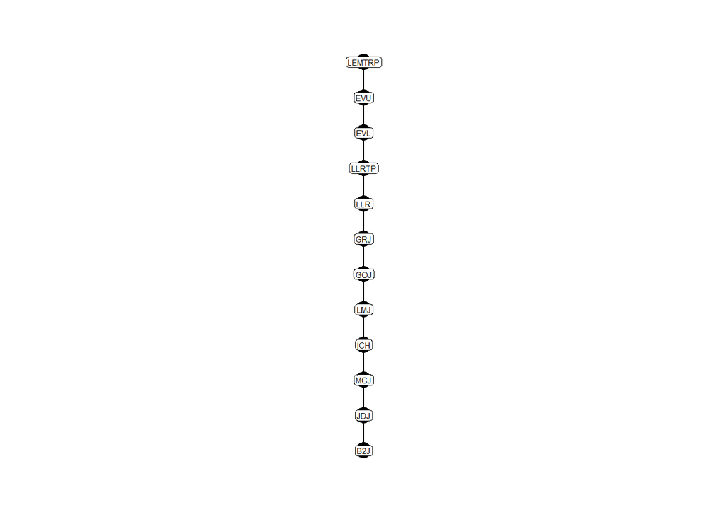

```r
plotNodes(parent_child)
```

## 5.3 Filter Strang Capture Histories

Once the detections have been compressed, and we can describe the relationship between nodes / sites with a parent-child table, we can assign direction of a tag between two nodes. For straightforward CJS models, one of the assumptions is that fish (or whatever creature is being studied) strictly moves forward through the detection points. When a CJS model describes survival through time, that is an easy assumption to make (i.e. animals are always only moving forward in time), but when performing a space-for-time type CJS as we are discussing here, that assumption could be violated.

One way to deal with non-straightforward movements is to filter the detections to only include those that appear to move in a straightforward manner. `PITcleanr` can help the user identify which tags have non-straightforward movements, and suggest what detections to keep, and which ones to filter out. `PITcleanr` contains a function, `filterDetections()`, to help determine which tags/individuals fail to meet the one-way travel assumption and need to be examined further. `filterDetections()` first runs `addDirection()`, and then adds two columns, `auto_keep_obs` and `user_keep_obs`. These are meant to indicate whether each row should be kept (i.e. marked TRUE) or deleted (i.e. marked FALSE). For tags that do meet the one-way travel assumption, both `auto_keep_obs` and `user_keep_obs` columns will be filled. If a fish moves back and forth along the same path, `PITcleanr` will indicate that only the last detection at each node should be kept.

In this analysis, we are also only concerned with tag movements after the fish has passed the Upper Lemhi rotary screw trap (site code LEMTRP). As mentioned above, some fish may have been tagged further upstream, prior to reaching LEMTRP, but we are not interested in their journey prior to LEMTRP, so we would like to filter observations of each tag prior to their detection at LEMTRP.

`PITcleanr` can perform multiple steps under a single wrapper function, `prepWrapper()`. `prepWrapper` can:

- start with a compressed detection file (`compress_obs`), OR
- start with the raw complete tag history (`cth_file`) and then compress them.
- filter out detections prior to a user-defined minimum date (`min_obs_date)` OR
- filter out detections prior to a user-defined starting node (`start_node`)
- add direction of movement to each detection (requires `parent_child`)
- note which tags have detections that follow one-way movements, and which tags do not
  - and suggest which detections to keep and which to filter out if needed,
  - including detections that occur after a user-defined maximum date (`max_obs_date`)
- add a column showing all the nodes where a tag was detected if that would be helpful to the user (`add_tag_detects`; uses the `extractTagObs` function from `PITcleanr`)
- save the output as an .xlsx or .csv file for the user to peruse with Excel or a similar program (`save_file = TRUE` and `file_name` can be set).

For our purposes, we will use the compressed detections and the parent-child table we built previously, filter for detections prior to LEMTRP and add all of the tag detections.

```r
prepped_df <-
  prepWrapper(compress_obs = comp_obs,
              parent_child = parent_child,
              start_node = "LEMTRP",
              add_tag_detects = T,
              save_file = F)
```

In our example, we are content deleting the observations that `PITcleanr` has flagged with `auto_keep_obs = FALSE`.

```r
prepped_df <-
  prepped_df |>
  mutate(
    across(user_keep_obs,
           ~ if_else(is.na(.),
                     auto_keep_obs,
                     .))) |>
  filter(user_keep_obs)
```

## 5.4 Form Capture Histories

Often, the inputs to a CJS model include a capture history matrix, with one row per tag, and columns of 0s and 1s describing if each tag was detected at each time period or node. We can easily construct such capture history matrices with the `buildCapHist()` function, using all the detections we determined to keep.

```r
# translate PIT tag observations into capture histories, one per tag
cap_hist <-
  buildCapHist(prepped_df,
               parent_child = parent_child,
               configuration = configuration)

# show an example
cap_hist
```

```
#> # A tibble: 3,622 × 2
#>    tag_code       cap_hist
#>    <chr>          <chr>
#>  1 384.1B79730415 100000000000
#>  2 384.1B7973117F 100000000000
#>  3 3D9.1C2DEF3A60 111010000000
#>  4 3DD.003D57F3DD 101001000000
#>  5 3DD.003D57F3DE 100000000000
#>  6 3DD.003D57F3DF 100000000000
#>  7 3DD.003D57F3E0 110000000000
#>  8 3DD.003D57F3E1 110000000000
#>  9 3DD.003D57F3E2 101011000000
#> 10 3DD.003D57F3E3 101000000000
#> # ℹ 3,612 more rows
```

To determine which position in the `cap_hist` string corresponds to which node, the user can run the `defineCapHistCols()` function (which is called internally within `buildCapHist()`).

```r
# to find out the node associated with each column
col_nodes <- defineCapHistCols(parent_child = parent_child,
                               configuration = configuration)
col_nodes
```

```
#>  [1] "LEMTRP" "EVU"    "EVL"    "LLRTP"  "LLR"    "GRJ"    "GOJ"    "LMJ"
#>  [9] "ICH"    "MCJ"    "JDJ"    "B2J"
```

Users have the option to keep each detection node as a separate column when creating the capture histories, by setting `drop_nodes = F`.

```r
cap_hist2 <-
  buildCapHist(prepped_df,
               parent_child = parent_child,
               configuration = configuration,
               drop_nodes = F)
cap_hist2
```

```
#> # A tibble: 3,622 × 14
#>    tag_code      cap_hist LEMTRP   EVU   EVL LLRTP   LLR   GRJ   GOJ   LMJ   ICH
#>    <chr>         <chr>     <dbl> <dbl> <dbl> <dbl> <dbl> <dbl> <dbl> <dbl> <dbl>
#>  1 384.1B797304… 1000000…      1     0     0     0     0     0     0     0     0
#>  2 384.1B797311… 1000000…      1     0     0     0     0     0     0     0     0
#>  3 3D9.1C2DEF3A… 1110100…      1     1     1     0     1     0     0     0     0
#>  4 3DD.003D57F3… 1010010…      1     0     1     0     0     1     0     0     0
#>  5 3DD.003D57F3… 1000000…      1     0     0     0     0     0     0     0     0
#>  6 3DD.003D57F3… 1000000…      1     0     0     0     0     0     0     0     0
#>  7 3DD.003D57F3… 1100000…      1     1     0     0     0     0     0     0     0
#>  8 3DD.003D57F3… 1100000…      1     1     0     0     0     0     0     0     0
#>  9 3DD.003D57F3… 1010110…      1     0     1     0     1     1     0     0     0
#> 10 3DD.003D57F3… 1010000…      1     0     1     0     0     0     0     0     0
#> # ℹ 3,612 more rows
#> # ℹ 3 more variables: MCJ <dbl>, JDJ <dbl>, B2J <dbl>
```

If the user wanted to find out how many tags were detected at each node, something like the following could be run:

```r
cap_hist2 |>
  select(-c(tag_code,
            cap_hist)) |>
  colSums()
```

```
#> LEMTRP    EVU    EVL  LLRTP    LLR    GRJ    GOJ    LMJ    ICH    MCJ    JDJ
#>   3622   1335   1948    257   1273    716     89     65      7     20     24
#>    B2J
#>     87
```

or directly from the prepared detection data:

```r
prepped_df |>
  group_by(node) |>
  summarize(n_tags = n_distinct(tag_code),
            .groups = "drop") |>
  mutate(across(node,
                ~ factor(.,
                         levels = col_nodes))) |>
  arrange(node)
```

```
#> # A tibble: 12 × 2
#>    node   n_tags
#>    <fct>   <int>
#>  1 LEMTRP   3622
#>  2 EVU      1335
#>  3 EVL      1948
#>  4 LLRTP     257
#>  5 LLR      1273
#>  6 GRJ       716
#>  7 GOJ        89
#>  8 LMJ        65
#>  9 ICH         7
#> 10 MCJ        20
#> 11 JDJ        24
#> 12 B2J        87
```

## 5.5 Fit a Cormack-Jolly-Seber Model

Now that we’ve wrangled all our detections into capture histories, we’re finally ready to fit a Cormack-Jolly-Seber (CJS) model. There are many options for doing this, but in this example, we’ll use the R package `marked`. Note that fitting a model like this (or nearly any kind of model) is outside the scope of the `PITcleanr` package. `PITcleanr` will help the user wrangle their data into a format that can be utilized in further analyses.

Please note that this vignette does not cover any of the details or assumptions behind a CJS model. Before attempting any analysis, the user should be aware of what’s involved and how to interpret the results.

The `marked` package requires the capture histories to be processed and design data created. Setting the formula for `Phi` (survival parameters) and `p` (detection parameters) to be `~ time` ensures that a separate survival and detection parameter will be estimated between and for each site. For further information about using the `marked` package, please see the package’s [CRAN site](https://cran.r-project.org/web/packages/marked/index.html), the package [vignette](https://cran.r-project.org/web/packages/marked/vignettes/markedVignette.html), or the paper describing it ([Laake, Johnson and Conn (2013)](https://besjournals.onlinelibrary.wiley.com/doi/10.1111/2041-210X.12065)).

```r
# load needed package
library(marked)

# process capture history into necessary format
cjs_proc <-
  cap_hist |>
  select(tag_code,
         ch = cap_hist) |>
  as.data.frame() |>
  process.data(model = "CJS")

# create design data
cjs_ddl <-
  make.design.data(cjs_proc)

# set model construction
Phi.time <- list(formula = ~ time)
p.time <- list(formula = ~ time)

# fit model
mod1 <- crm(data = cjs_proc,
            ddl = cjs_ddl,
            model.parameters = list(Phi = Phi.time,
                                    p = p.time),
            hessian = T)
```

Survival and detection parameter estimates can be extracted, and the user can label them by the reaches and sites they refer to.

```r
# pull out parameter estimates
est_preds <- predict(mod1) |>
  map(.f = as_tibble)

est_preds$Phi <-
  est_preds$Phi |>
  left_join(parent_child |>
              left_join(buildNodeOrder(parent_child),
                        by = join_by(child == node)) |>
              arrange(node_order) |>
              mutate(occ = node_order - 1) |>
              select(occ, parent, child) |>
              unite(col = "reach",
                    parent,
                    child,
                    sep = "_"),
            by = join_by(occ)) |>
  relocate(reach,
           .after = occ)

est_preds$p <-
  est_preds$p |>
  mutate(site = rev(parent_child$child)) |>
  relocate(site,
           .after = occ)
```

Now we can plot estimate survival (`Phi`) and examine the estimates in a table.

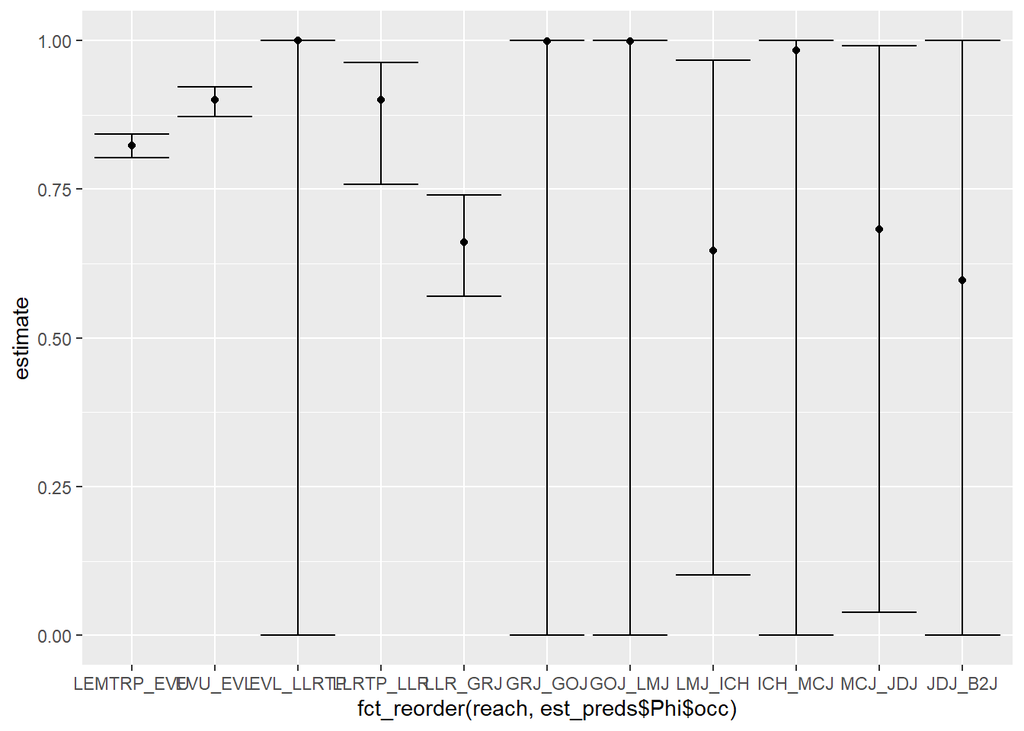

```r
est_preds$Phi %>%
  ggplot(aes(x = fct_reorder(reach, est_preds$Phi$occ), y = estimate)) +
  geom_point() +
  geom_errorbar(aes(ymin = lcl, ymax = ucl))
```

```r
# examine the estimates
# Survival
est_preds$Phi |>
  mutate(across(where(is.numeric),
         ~ round(., digits = 3))) %>%
  kable() %>%
  kable_styling(full_width = TRUE,
                bootstrap_options = "striped")
```

| time | occ | reach | estimate | se | lcl | ucl |
| --- | --- | --- | --- | --- | --- | --- |
| 1 | 1 | LEMTRP_EVU | 0.824 | 0.010 | 0.803 | 0.843 |
| 2 | 2 | EVU_EVL | 0.900 | 0.013 | 0.872 | 0.922 |
| 3 | 3 | EVL_LLRTP | 1.000 | 0.047 | 0.000 | 1.000 |
| 4 | 4 | LLRTP_LLR | 0.901 | 0.048 | 0.759 | 0.963 |
| 5 | 5 | LLR_GRJ | 0.661 | 0.044 | 0.570 | 0.741 |
| 6 | 6 | GRJ_GOJ | 0.999 | 0.029 | 0.000 | 1.000 |
| 7 | 7 | GOJ_LMJ | 0.999 | 0.021 | 0.000 | 1.000 |
| 8 | 8 | LMJ_ICH | 0.648 | 0.324 | 0.102 | 0.968 |
| 9 | 9 | ICH_MCJ | 0.984 | 0.191 | 0.000 | 1.000 |
| 10 | 10 | MCJ_JDJ | 0.683 | 0.440 | 0.039 | 0.991 |
| 11 | 11 | JDJ_B2J | 0.598 | 0.945 | 0.001 | 1.000 |

We can also look at the estimates of detection probabilities.

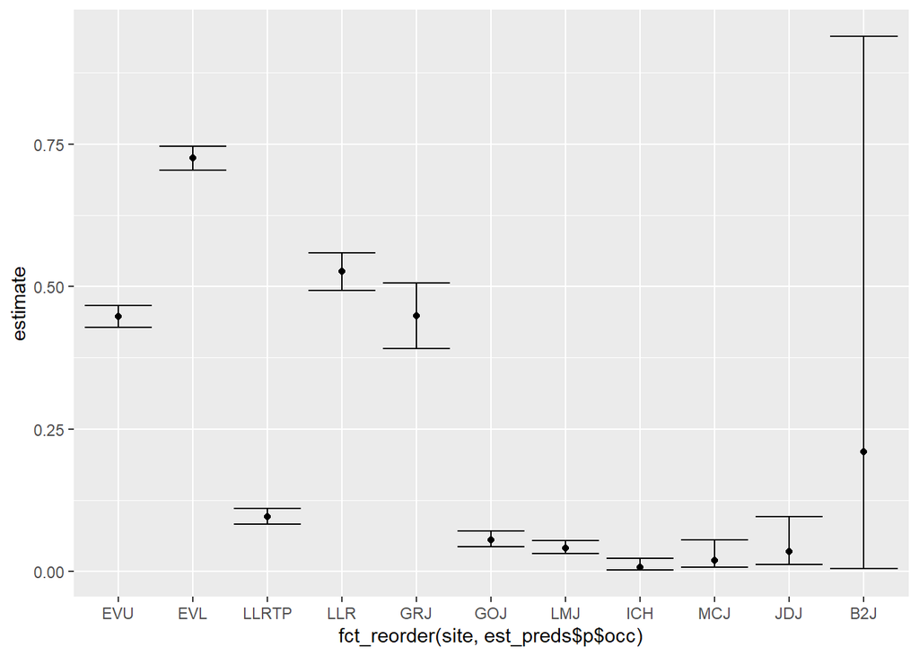

```r
est_preds$p %>%
  ggplot(aes(x = fct_reorder(site, est_preds$p$occ), y = estimate)) +
  geom_point() +
  geom_errorbar(aes(ymin = lcl, ymax = ucl))
```

```r
# Detection
est_preds$p |>
  mutate(across(where(is.numeric),
         ~ round(., digits = 3))) %>%
  kable() %>%
  kable_styling(full_width = TRUE,
                bootstrap_options = "striped")
```

| time | occ | site | estimate | se | lcl | ucl |
| --- | --- | --- | --- | --- | --- | --- |
| 2 | 2 | EVU | 0.447 | 0.010 | 0.428 | 0.467 |
| 3 | 3 | EVL | 0.725 | 0.011 | 0.704 | 0.745 |
| 4 | 4 | LLRTP | 0.096 | 0.007 | 0.082 | 0.111 |
| 5 | 5 | LLR | 0.526 | 0.017 | 0.493 | 0.559 |
| 6 | 6 | GRJ | 0.448 | 0.029 | 0.391 | 0.506 |
| 7 | 7 | GOJ | 0.056 | 0.007 | 0.044 | 0.071 |
| 8 | 8 | LMJ | 0.041 | 0.006 | 0.031 | 0.053 |
| 9 | 9 | ICH | 0.007 | 0.004 | 0.002 | 0.023 |
| 10 | 10 | MCJ | 0.020 | 0.010 | 0.007 | 0.055 |
| 11 | 11 | JDJ | 0.035 | 0.018 | 0.012 | 0.096 |
| 12 | 12 | B2J | 0.209 | 0.343 | 0.005 | 0.939 |

In this example, a user might be interested in the cummulative survival of fish from the Upper Lemhi screw trap to certain dams like Lower Granite, McNary, and John Day. These can be obtained by multiplying survival estimates up to the location of interest. Because the final survival and detection probabilties are confounded in this type of CJS model, we can’t estimate cummulative survival to Bonneville dam (B2J) unless we added detection sites either within the estuary or of adults returning to Bonneville.

```r
# cumulative survival to Lower Granite, McNary and John Day dams
est_preds$Phi |>
  # group_by(life_stage) |>
  summarize(lower_granite = prod(estimate[occ <= 6]),
            mcnary = prod(estimate[occ <= 10]),
            john_day = prod(estimate[occ <= 11]))
```

```
#> # A tibble: 1 × 3
#>   lower_granite mcnary john_day
#>           <dbl>  <dbl>    <dbl>
#> 1         0.441  0.191    0.114
```

## 5.6 Warnings

Estimating fish survival is complex and requires multiple assumptions. Be careful following this script and reproducing results with your own data. We do not guarantee the steps listed above will yield perfect results, and they will require adjustments to fit your needs. The steps were only provided to get you started with `PITcleanr`. Please reach out to the authors if you have questions or need assistance using the package.